**OPTIMIZATION**

|  | by Seungchul Lee iSystems Design Lab http://isystems.unist.ac.kr/ UNIST |
| --- | --- |

Table of Contents

# 1. OPTIMIZATION

- an important tool in 1) engineering problem solving and 2) decision science
- peolple optimize
- nature optimizes

[figure not shown]

(source: http://nautil.us/blog/to-save-drowning-people-ask-yourself-what-would-light-do)

**3 key components**

1. objective
2. decision variable or unknown
3. constraints

**Procedures**

1. The process of identifying objective, variables, and constraints for a given problem is known as "modeling"
2. Once the model has been formulated, optimization algorithm can be used to find its solutions.

In mathematical expression

$$\begin{align*} \min_{x} \quad &f(x) \\ \text{subject to} \quad &g_i(x) \leq 0, \qquad i=1,\cdots,m \end{align*} $$

Remarks) equivalent

$$\begin{align*} \min_{x} f(x) \quad&\leftrightarrow \quad \max_{x} -f(x)\\ \quad g_i(x) \leq 0\quad&\leftrightarrow \quad -g_i(x) \geq 0\\ h(x) = 0 \quad&\leftrightarrow \quad \begin{cases} h(x) \leq 0 \quad \text{and} \\ h(x) \geq 0 \end{cases} \end{align*} $$

The good news: for many classes of optimization problems, people have already done all the "hardwork" of developing numerical algorithms

- A wide range of tools that can take optimization problems in "natural" forms and compute a solution

# 2. LINEAR PROGRAMMING (Convex)

**Objective function and Constraints are both linear**

$$ \begin{align*} \max \; & \; 3x_1 + \frac{3}{2}x_2 \quad \quad \leftarrow \text{objective function}\\ \\ \text{subject to} \; & -1 \leq x_1 \leq 2 \quad \leftarrow \text{constraints}\\ & \quad 0 \leq x_2 \leq 3 \end{align*} $$

Method 1: **graphical approach**

$$ 3 x_1 + 1.5 x_2 = C \qquad \Rightarrow \qquad x_2 = -2 x_1 + \frac{2}{3}C $$

[figure not shown]

Method 2: **CVX solver**

## LP Example

$$ \begin{array}{Icr}\begin{align*} \max_{x} \quad & x_1 + x_2 \\ \text{subject to} \quad & 2x_1 + x_2 \leq 29 \\ & x_1 + 2x_2 \leq 25 \\ & x_1 \geq 2 \\ & x_2 \geq 5 \end{align*}\end{array} \quad\implies\quad \begin{array}{I} \quad \min_{x} \quad & - \begin{bmatrix} 1 & 1 \end{bmatrix} \begin{bmatrix} x_1 \\ x_2 \end{bmatrix} \\ \text{subject to} \quad & \begin{bmatrix} 2 & 1 \\ 1 & 2 \end{bmatrix} \begin{bmatrix} x_1 \\ x_2 \end{bmatrix} \leq \begin{bmatrix} 29 \\ 25 \end{bmatrix} \\ & \begin{bmatrix} 2 \\ 5 \end{bmatrix} \leq \begin{bmatrix} x_1 \\ x_2 \end{bmatrix} \leq \begin{bmatrix} \\ \\ \end{bmatrix} \end{array} $$

### CVX code

- Many examples will be provided throughout the class
- below example
  - http://cvxr.com/cvx/examples/ $\rightarrow$ Miscellaneous examples
  - http://inst.eecs.berkeley.edu/~ee127a/book/login/exa_lp_drug_manuf.html

```python
import numpy as np
import matplotlib.pyplot as plt
import cvxpy as cvx
import warnings
from cvxopt import matrix, solvers
```

```python
# LP example2

f = np.array([[1, 1]])
A = np.array([[2, 1], [1, 2]])
b = np.array([[29], [25]])
lb = np.array([[2], [5]])



x = cvx.Variable(2,1)

objective = cvx.Maximize(f*x)
constraints = [A*x <= b, lb <= x]
prob = cvx.Problem(objective, constraints)
result = prob.solve()

print (x.value)
print (result)
```

```
[[ 11.]
 [  7.]]
17.999999998643816
```

# 3. QUADRATIC PROGRAMMING (Convex)

The problem can be found at http://courses.csail.mit.edu/6.867/wiki/images/e/ef/Qp-quadprog.pdf

$$ \begin{array}{Icr}\begin{align*} \min \quad &\frac{1}{2}x^2+3x+4y \\ \text{subject to} \quad & x+3y \geq 15 \\ & 2x+5y \leq 100 \\ & 3x+4y \leq 80 \\ & x,y \geq 0 \\ \end{align*}\end{array} \quad\implies\quad \begin{array}{I} \min_{x} \quad & \frac{1}{2}x^THx + f^Tx \\ \text{subject to} \quad & Ax \leq b \\ & A_{eq}x = b_{eq} \\ & LB \leq x \leq UB \end{array} $$

## CVX code

http://inst.eecs.berkeley.edu/~ee127a/book/login/l_lqp_standard.html

```python
f = np.array([[3], [4]])
H = np.array([[1, 0], [0, 0]])
A = np.array([[-1, -3], [2, 5], [3, 4]])
b = np.array([[-15], [100], [80]])
LB = np.array([[0], [0]])

x = cvx.Variable(2)
objective = cvx.Minimize(cvx.quad_form(x, H) + f.T*x)
constraints = [A*x <= b, x >= LB]
prob = cvx.Problem(objective, constraints)
result = prob.solve()

print(x.value)
print(result)
```

```
[[  7.37787558e-10]
 [  5.00000000e+00]]
20.00000000034897
```

**Another example**

```python
x = cvx.Variable(2)
```

```python
x = cvx.Variable(2)
objective = cvx.Minimize(-3*x[0] - 3/2*x[1])
constraints = [-1 <= x[0], x[0] <= 2, 0 <= x[1], x[1] <= 3]
prob = cvx.Problem(objective, constraints)
result = prob.solve()

print(x.value)
print(result)
```

```
[[ 1.99999999]
 [ 2.99999999]]
-10.499999966365493
```

# 4. LEAST-SQUARES

The problem can be found at Computational Methods for Data Analysis, Chap 17

## Python(cvxpy) code

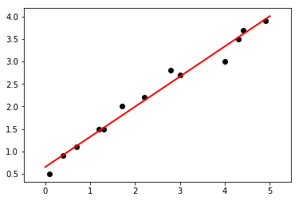

```
Theta =
[[ 0.67129519]
 [ 0.65306531]]
```

```python
%matplotlib inline
x = np.array([[0.1, 0.4, 0.7, 1.2, 1.3, 1.7, 2.2, 2.8, 3.0, 4.0, 4.3, 4.4, 4.9]]).transpose()
y = np.array([[0.5, 0.9, 1.1, 1.5, 1.5, 2.0, 2.2, 2.8, 2.7, 3.0, 3.5, 3.7, 3.9]]).transpose()


m = y.shape[0]
A = np.concatenate((x,np.ones((m,1))),1)


theta = cvx.Variable(A.shape[1])
objective = cvx.Minimize(cvx.norm2(A*theta - y))
constraints = []
prob = cvx.Problem(objective, constraints)
result = prob.solve()




xp = np.linspace(0, 5, 500)
yp = theta[0].value*xp + theta[1].value

plt.plot(x, y, 'ko')
plt.plot(xp, yp, 'r-', linewidth = 2)
plt.axis('equal')
plt.show()
print("Theta = ")
print(theta.value)
```

# 5. INTEGER PROGRAMMING (non-convex)

- some or all of the variables are restricted to be integers. In many settings the term refers to integer linear programming (ILP), in which the objective function and the constraints (other than the integer constraints) are linear.

## 5.1. Mixed Integer Linear Programming (MILP)

A mixed-integer linear program is a problem with

- Linear objective function, $f^T x$, where $f$ is a column vector of constants, and $x$ is the column vector of unknowns
- Bounds and linear constraints, but no nonlinear constraints
- Restrictions on some components of $x$ to have integer values

**MILP Example 1**

$$\begin{align*} \min_{x} \quad & \begin{bmatrix} -3 & -1 \end{bmatrix} \begin{bmatrix} x_1 \\ x_2 \end{bmatrix} \\ \text{subject to} \quad & \begin{bmatrix} 17 & 11 \end{bmatrix} \begin{bmatrix} x_1 \\ x_2 \end{bmatrix} \leq 83 \\ & \begin{bmatrix} 0 \\ 0 \end{bmatrix} \leq \begin{bmatrix} x_1 \\ x_2 \end{bmatrix} \leq \begin{bmatrix} 3 \\ 7 \end{bmatrix} \\ & x_1, x_2 \in \mathbb{Z} \; \text{(integer)} \end{align*} $$

**MIP Example 2**

$$\begin{align*} \min_{x} \quad & \begin{bmatrix} -3 & -2 & -1 \end{bmatrix} \begin{bmatrix} x_1 \\ x_2 \\ x_3 \end{bmatrix} \\ \text{subject to} \quad & \begin{bmatrix} 1 & 1 & 1 \end{bmatrix} \begin{bmatrix} x_1 \\ x_2 \\ x_3 \end{bmatrix} \leq 7 \\ & \begin{bmatrix} 4 & 2 & 1 \end{bmatrix} \begin{bmatrix} x_1 \\ x_2 \\ x_3 \end{bmatrix} = 12 \\ & 0 \leq \begin{bmatrix} x_1 \\ x_2 \\ x_3 \end{bmatrix} \\ & x_3 \in \{0,1\} \end{align*} $$

### Integer programming using cvx

- Integer programming is not a part of convex optimzation problem.

## 5.2. Binary Integer Programming

each variable can only take on the value of 0 or 1. This may represent the selection or rejection of an option, the turning on or off of switches, a yes/no answer, or many other situations.

$$ \begin{align*} \min \quad & x_1 + x_2 + x_3 + x_4 + x_5 + x_6 \\ \\ \text{subject to} \quad & x_1 + x_2 \geq 1 \\ & x_1 + x_2 + x_6\ \geq 1 \\ & x_3 + x_4 \geq 1 \\ & x_3 + x_4 + x_5 \geq 1 \\ & x_4 + x_5 + x_6 \geq 1 \\ & x_5 + x_6 \geq 1 \\ & x_1 \ x_2 \ x_3 \ x_4 \ x_5 \ x_6 \in \{0, 1\} \\ \end{align*}$$

### Integer programming using cvx

- Integer programming is not a part of convex optimzation problem.

# 6. General or Standard Forms

1. Linear programming $$\begin{align*} \min_{x} \quad & f^Tx \\ \text{subject to} \quad & Ax \leq b\\ & A_{eq}x = b_{eq}\\ & LB \leq x \leq UB \end{align*} $$
2. Integer programming $$\begin{align*} \min_{x} \quad & f^Tx \\ \text{subject to} \quad & Ax \leq b\\ & A_{eq}x = b_{eq}\\ & LB \leq x \leq UB\\ & x \in \mathbb{Z} \;\text{(integer)} \end{align*} $$
3. Mixed integer linear programming $$\begin{align*} \min_{x,z} \quad & f^T \begin{bmatrix} x \\ z \end{bmatrix} \\ \text{subject to} \quad & A \begin{bmatrix} x \\ z \end{bmatrix} \leq b \\ & A_{eq} \begin{bmatrix} x \\ z \end{bmatrix} = b_{eq}\\ & LB \leq \begin{bmatrix} x \\ z \end{bmatrix} \leq UB \\ & x \in \mathbb{R} \;\text{(real)} \\ & z \in \mathbb{Z} \end{align*} $$
4. Binary integer programming $$\begin{align*} \min_{x} \quad & f^Tx \\ \text{subject to} \quad & Ax \leq b \\ & A_{eq}x = b_{eq} \\ & LB \leq x \leq UB \\ & x \in \{0,1\} \end{align*} $$
5. Quadratic programming $$\begin{align*} \min_{x} \quad & \frac{1}{2}x^THx + f^Tx \\ \text{subject to} \quad & Ax \leq b \\ & A_{eq}x = b_{eq} \\ & LB \leq x \leq UB \end{align*} $$

# 7. Gradient Descent

Goal : Find $\omega^{*}$ that minimizes

$$f(\omega) = \lVert X\omega - y \rVert ^2_2$$

- Closed form solution exists
- Gradient Descent is iterative (Intuition: go downhill !)

[figure not shown]

$$\text{Scalar objective:}\;\; f(\omega) = \lVert \omega x - y \rVert^2_2 = \sum_{j=1}^{n}\left( \omega x^{(j)} - y^{(j)} \right)^2$$

```python
%%html
<iframe src="./image_files/gradient.pdf#view=FitH", width=700, height = 400" frameborder="0"></iframe>
```

[interactive chart not shown]

## Example

$$ \begin{align*} \min& \quad (x_1-3)^{2} + (x_2-3)^{2}\\ =\min& \quad \frac{1}{2} \begin{bmatrix} x_1 & x_2 \end{bmatrix} \begin{bmatrix} 2 & 0 \\ 0 & 2 \end{bmatrix} \begin{bmatrix} x_1 \\ x_2 \end{bmatrix} - \begin{bmatrix} 6 & 6 \end{bmatrix} \begin{bmatrix} x_1 \\ x_2 \end{bmatrix} + 18 \end{align*} $$

- update rule

$$ \omega_{i+1} = \omega_{i} - \alpha_i \nabla f(\omega_i)$$

```python
H = np.array([[2, 0], [0, 2]])
f = np.array([[6], [6]])
b = 18

x = np.zeros([2, 1])
alpha = 0.2

for i in range(25):
    g = np.dot(H, x) - f
    x = x - alpha*g

x
```

```
array([[ 2.99999147],
       [ 2.99999147]])
```

```python
%%javascript
$.getScript('https://kmahelona.github.io/ipython_notebook_goodies/ipython_notebook_toc.js')
```